# Consumer Panel Experience

Author

Simran Kaur

Published

## My experience

I joined [YouGov](https://account.yougov.com/us-en/account) and explored its questions and Daily Chat about personal interests and hobbies. I found the chat survey interesting because it felt conversational, allowed multiple selections, and showed live results. These screenshots show what stood out to me, including a few questions that made me stop and think about how to answer.

## An open-ended question

I found the question “What’s on your mind?” confusing/ hard to answer because it gave me the freedom to talk about something important to me. At the same time, it was so broad that I was not sure where to start or how much to write. This question is an example of how an open-ended question can invite expression but also leave a participant unsure about what is expected.

[figure not shown]

What’s on your mind?

## The chat survey format

I found this chat survey interesting because it felt more like a conversation than a regular questionnaire. It showed one question at a time, which made it easy to follow.

[figure not shown]

Daily Chat introduction and weekly hobby time

## Specific response options

I also noticed the fact that how this question gave specific examples of hobbies, so one could quickly find activities that matched my interests. Having “Something else” and “Not sure” was useful too. I noticed that some options combined activities, such as “Reading or writing.” That made me wonder how the researchers would distinguish between people who enjoy reading and those who enjoy writing or how this can help narrow down a research.

[figure not shown]

Hobby question and answer choices

## Multiple selections

I liked being able to select multiple answers, it is specifically makes survey easy to follow through as one can enjoy more than one activity and don’t get caught up selecting one option in a survey. I selected four options, and the highlighted buttons made it easy to see what I had chosen. This felt more accurate than having to pick only one hobby.

[figure not shown]

Four hobby options selected

## Live results

I found the live results especially interesting because I could immediately see how other participants answered. It made the chat feel interactive and kept me curious about the next question. I also noticed that the percentages could add up to more than 100% because we could select several activities.

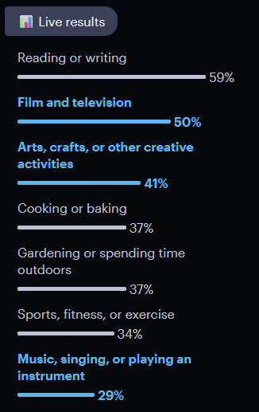

Results displayed after answering

## A statement about the results

This statement was an interesting add on in this survey, making the participants feel comfortable answering. Seeing percentages can make results look convincing, so I thought it was helpful to explain their limitations directly.

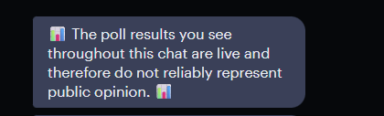

Live-results limitation statement

## Space to explain an answer

I liked having an area to express my thoughts after selecting an answer. The question “Why do you say that?” can allow participants can allow survey participants to explain a reason in their own words, share something which they couldn’t in survey etc. I also appreciated knowing that comments would be visible anonymously and that I could skip this part.

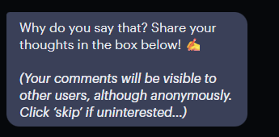

Optional written follow-up

## Lessons for my CEP project

Taking part helped me think about what makes a survey engaging from the participant’s side. For our TBFI project, I would keep the wording simple, give clear answer options, and allow multiple selections when needed. I would also include a short optional question so participants can explain their thoughts. The broad question and weekly time estimate reminded me to give enough direction and use clear time ranges. Although I enjoyed the live results, I would show results at the end of our survey to reduce the chance of influencing later answers. I would also explain what our dashboard results can and cannot tell us.

## Publication Links

- [YouGov](https://account.yougov.com/us-en/account)
- [GitHub Repository](https://github.com/Simrank-DM/IBM6500-F26)
- [Published Report](https://simrank-dm.github.io/IBM6500-F26/MO7/Simran-Kaur-IC5-2-Consumer-Panel.html)